# Mobile Analytics

Mason Hansen

11/18/2018

# Data Preparation

```r
library(dplyr)
library(DescTools)
library(psych)
library(corrplot)
library(RColorBrewer)
library(ggplot2)
setwd('/Users/mason/Desktop/MSBA/Fall18/BANA277_f18/Mobile_Analytics/')
data <- read.csv('Geo-Fence Analytics.csv')
options(scipen=999)
#CreateDummy Variables
attach(data)
data$imp_large <- ifelse(imp_size == "728x90",1,0)
data$cat_entertainment <- ifelse(app_topcat == "IAB1" | app_topcat =="IAB1-6",1,0)
data$cat_social <- ifelse(app_topcat == "IAB14",1,0)
data$cat_tech <- ifelse(app_topcat == "IAB19-6",1,0)
data$as_ios <- ifelse(device_os == "iOS",1,0)
data$weight<- ifelse(data$didclick == 1,1,.001)
#Other variables
distance_LatLong <- function(Lat1,Lon1,Lat2,Lon2){
  6371 * acos(cos(DegToRad(Lat1)) * cos(DegToRad(Lat2)) * cos(DegToRad(Lon1) - DegToRad(Lon2)) + sin(DegToRad(Lat1)) * sin(DegToRad(Lat2)))
}
for (i in 1:nrow(data)){
  data$distance[i] <- distance_LatLong(device_lat[i],device_lon[i],geofence_lat[i],geofence_lon[i])
}
data$distance_squared <- data$distance^2
data$ln_app_review_vol <-log(app_review_vol)
detach(data)
head(data)
```

```
##   imp_size app_id                                          app_name
## 1   320x50     62 Dictionary.com Android APP - First look inventory
## 2   320x50     62 Dictionary.com Android APP - First look inventory
## 3   320x50     62 Dictionary.com Android APP - First look inventory
## 4   320x50     62 Dictionary.com Android APP - First look inventory
## 5   320x50     62 Dictionary.com Android APP - First look inventory
## 6   320x50     62 Dictionary.com Android APP - First look inventory
##   app_pub app_topcat app_review_vol app_review_val device_lat device_lon
## 1               IAB5          63228            4.6   33.84575  -117.8250
## 2               IAB5          63228            4.6   33.85843  -117.8605
## 3               IAB5          63228            4.6   33.77808  -117.8752
## 4               IAB5          63228            4.6   33.87387  -117.8174
## 5               IAB5          63228            4.6   33.94048  -117.9675
## 6               IAB5          63228            4.6   33.80514  -118.0167
##   device_zip device_os geofence_lat geofence_lon gepfence_radius didclick
```

[output cut: 20 more lines]

# Descriptive Stats

## Summary Statistics

```r
ds_vars <- c('didclick','distance','imp_large','cat_entertainment','cat_social',
             'cat_tech','as_ios','ln_app_review_vol','app_review_val')
df_vars <- data[ds_vars]
x<- describe(df_vars)
attach(x)
newx<- cbind(mean,median,sd,min,max);
rownames(newx)<-ds_vars
newx
```

```
##                           mean    median         sd        min      max
## didclick           0.006811059  0.000000 0.08224794 0.00000000  1.00000
## distance           2.983737139  2.020864 2.64852620 0.02075894 11.78666
## imp_large          0.230876800  0.000000 0.42139550 0.00000000  1.00000
## cat_entertainment  0.283925736  0.000000 0.45090308 0.00000000  1.00000
## cat_social         0.125124417  0.000000 0.33086130 0.00000000  1.00000
## cat_tech           0.517846126  1.000000 0.49968347 0.00000000  1.00000
## as_ios             0.250363997  0.000000 0.43322443 0.00000000  1.00000
## ln_app_review_vol 10.056798904 10.087225 0.63696194 7.08086790 12.93770
## app_review_val     3.654872622  3.400000 0.36081251 1.40000000  4.70000
```

```r
detach(x)
```

## Correlations

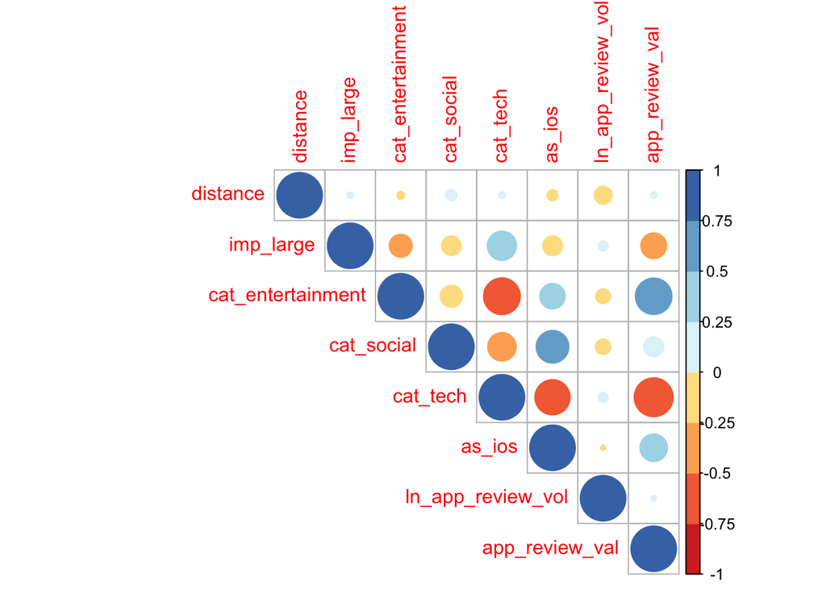

```r
thresh <- 0
correlations <- cor(df_vars[,-1])
correlations0 <- correlations
diag(correlations0) <- 0
new<- sort(unique(c(which(abs(correlations0)> thresh,arr = TRUE))))
correlations <- correlations[new,new]
corrplot(correlations[new,new], method = "circle", type = "upper", col = brewer.pal(n=8, name = "RdYlBu"))
```

- For variables with a strong correlation, either positive or negative, the pairings are included as follows:
  - Category: Technology vs. Category: Entertainment, r = ~ (-0.653)
  - Category: Technology vs. iOS Device, r = ~ (-0.599)
  - Category: Technology vs. App Review Valance, r = ~ (-0.732)
  - Category Entertainment vs. App Review Valance, r = ~ 0.642

## Click Through Rate by Distance (Binned)

```r
data <-
  data %>%
  mutate(dist_bin=cut(distance, breaks=c(0, 0.5, 1,2,4,7,10, Inf), labels=c("1","2","3","4","5","6","7")))
dist_bin_freq <- as.data.frame.matrix(table(data$dist_bin, data$didclick))
dist_bin_freq$total <- dist_bin_freq$`0` + dist_bin_freq$`1`
dist_bin_freq$ctr <- dist_bin_freq$`1`/dist_bin_freq$total
colnames(dist_bin_freq)<- c("No Click","Did Click","Total", "Click Rate");
rownames(dist_bin_freq) <- c('0-0.5','0.5-1','1-2','2-4','4-7','7-10','>10')
dist_bin_freq
```

```
##       No Click Did Click Total  Click Rate
## 0-0.5     7264        60  7324 0.008192245
## 0.5-1    19243       159 19402 0.008195031
## 1-2      33235       235 33470 0.007021213
## 2-4      30336       177 30513 0.005800806
## 4-7      18151       116 18267 0.006350249
## 7-10      7661        54  7715 0.006999352
## >10       4849        27  4876 0.005537326
```

# Plots of Interest

## Boxplot

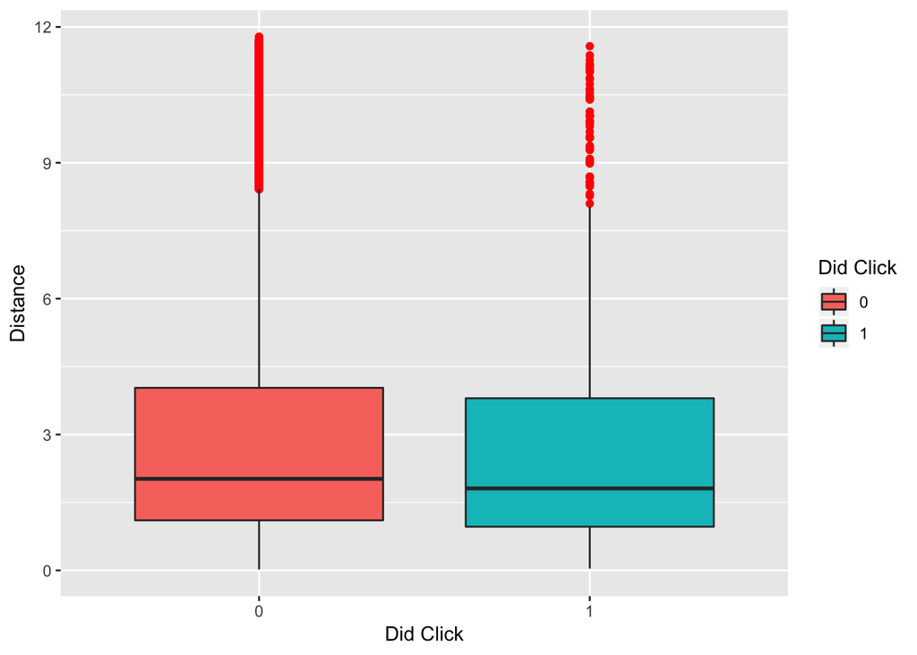

```r
didclick.sum<- aggregate(data$distance~data$didclick,data,mean)
ggplot(data, aes(x=as.factor(data$didclick),y=data$distance,fill=as.factor(data$didclick)))+
  geom_boxplot(outlier.colour = "red")+
  labs(x="Did Click",y="Distance")+
  scale_fill_discrete(name= "Did Click")
```

## Click Through Rate by Distance (Binned)

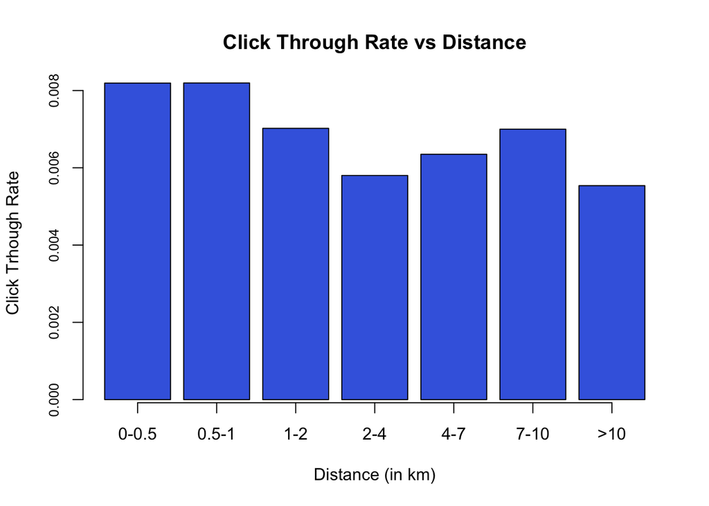

```r
barplot(dist_bin_freq$`Click Rate`,
        xlab = "Distance (in km)", ylab = "Click Trhough Rate",
        main = "Click Through Rate vs Distance",
        col = "RoyalBlue",
        axis.lty = 1,
        names.arg = c('0-0.5','0.5-1','1-2','2-4','4-7','7-10','>10'),
        cex.axis = .8)
```

- Impressions with smallest distance between device and impression location of interest perform best in click through rate.
- For distances of (0 to 0.5) kilometers, the click through rate was 0.008192 and for distances (0.5 to 1) kilometers, the click through rate was 0.008195. Thus, it appears that the highest values of click through rates occur among those impressions that had the smallest distances between the device and the impressions’ geofence location of interest.

# Logistic Regression

```r
mod2<- glm(didclick~ distance + distance_squared+imp_large+cat_entertainment+
             cat_social+cat_tech+as_ios+ln_app_review_vol+
             app_review_val,family = "binomial", data = data)
summary(mod2)
```

```
##
## Call:
## glm(formula = didclick ~ distance + distance_squared + imp_large +
##     cat_entertainment + cat_social + cat_tech + as_ios + ln_app_review_vol +
##     app_review_val, family = "binomial", data = data)
##
## Deviance Residuals:
##     Min       1Q   Median       3Q      Max
## -0.1510  -0.1272  -0.1148  -0.1042   3.4025
##
## Coefficients:
##                    Estimate Std. Error z value          Pr(>|z|)
## (Intercept)       -6.616818   0.896958  -7.377 0.000000000000162 ***
## distance          -0.117927   0.045073  -2.616          0.008888 **
## distance_squared   0.009166   0.004362   2.102          0.035583 *
## imp_large         -0.352164   0.091782  -3.837          0.000125 ***
## cat_entertainment -0.096143   0.178941  -0.537          0.591069
## cat_social        -0.226695   0.211394  -1.072          0.283550
## cat_tech           0.687657   0.176312   3.900 0.000096102347522 ***
## as_ios             0.385895   0.126361   3.054          0.002259 **
## ln_app_review_vol  0.030512   0.063037   0.484          0.628368
## app_review_val     0.323831   0.186656   1.735          0.082757 .
## ---
## Signif. codes:  0 '***' 0.001 '**' 0.01 '*' 0.05 '.' 0.1 ' ' 1
##
## (Dispersion parameter for binomial family taken to be 1)
##
##     Null deviance: 9912.5  on 121566  degrees of freedom
## Residual deviance: 9857.1  on 121557  degrees of freedom
## AIC: 9877.1
##
## Number of Fisher Scoring iterations: 8
```

```r
sig_coeff<-mod2$coefficients[c(2,4,7,8)]
odds<- exp(sig_coeff);odds
```

```
##  distance imp_large  cat_tech    as_ios
## 0.8887606 0.7031648 1.9890505 1.4709300
```

- Results from the logistic regression:
- Significant factors:
  - Distance and Distance Squared
  - Large Impressions (“728x90”)
  - Category: Technology
  - iOS Devices
- Coefficients: -0.1179273, -0.352164, 0.6876574, 0.3858948
- Notice that distance and impression size have negative coefficients.
  - For distance, for every unit increase in distance (km), the added value to the model of clicking will be decreased by -0.1179273, p-val = 0.00888.
  - For impression size, if the impression is large (“728x90”), then the added value to the model of clicking will be decreased by -0.352164, p-val = 0.000125.
- Both Category: Technology and iOS Device, when true will add 0.6876574, p-val =9.61e-5 and 0.3858948, p-val = 0.00226 respectively.
- Odds Ratios
  - Distance 0.8887606. As distance increases by 1 km, the probability of a customer clicking decreases by ~ 11%.
  - Large Impression 0.7031648. If the impression is large (“728x90”), then the probability of a customer clicking decreases by ~ 29.7%.
  - Category : Technology 1.9890505. If the category is technology, then the probability of a customer clicking increases by ~98.9%.
  - iOS Devices 1.47093. If the device is iOS, the probability of a customer clicking increases by ~47%.
- For a company or app developer that wants to reach potential customers by advertising impressions, they should focus on customers that are a) within close proximity to the business, b) focus on smaller impressions, c) focus on ads that are in the technology category, and d) for those using an iOS device.